# Web scraping and webcomics

Zach Burchill

2015-12-12 20:00:00

It started with the thought: “Can I use statistical modelling to tell me when I should stop hoping a webcomic will keep updating?” There are few feelings worse than returning to a comic week after week in the vain hope its creator will start releasing new strips again.

And while that model is still in the works, I’ve gotten my hands on a bunch of cool data in the meantime.

## Web scraping

In order to make a model, you generally need data to train it on. Most webcomics don’t have a downloadable R database of all their updates, so you’ll have to get the data yourself. You can click through potentially thousands of pages, recording the dates manually, or you can use **web scraping** to do it automatically.

If you use Python and want an incredibly easy-to-get-into web scraping tool, check out the Python module, [Beautiful Soup](http://www.crummy.com/software/BeautifulSoup/) (I used `bs4`). In a nutshell, it loads HTML pages and parses the elements into a tree automatically. Extracting, say, all the `img` tags on a page can be as simple as: `soup.find_all('img')`. Beautiful Soup is pretty simple to learn and the [documentation](http://www.crummy.com/software/BeautifulSoup/bs4/doc/) makes it a breeze.

## Broodhollow updates: a story of an author’s life

“Broodhollow.” The name sounds like a title that a moody fifteen-year-old would come up with, but it is **absolutely** my favorite webcomic. **Ever.** The art is beautiful and the story writing is some of the best I’ve ever read. One part comedy and two parts creeping horror, if author [Kris Straub](http://studios.chainsawsuit.com/) can finish the comic with a *tenth* of the talent he’s exhibited so far, I’m confident this will go down as one of the great graphic novels of our generation.

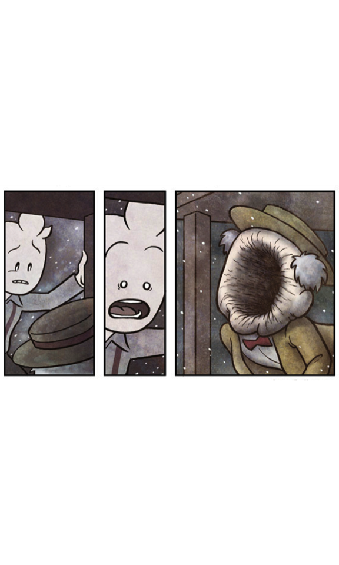

A sample of Kris Staub’s genius.

```r
library(png)
library(grid)
img <- readPNG("/Users/zburchill/Desktop/broodhollow_snippet.png")
grid.raster(img)
```